# Lab 3: Exploring Happiness

Due: 10/03/2019 by 10 pm

Aashwin Lamsal, Eric Friesth

09/26/2019

## Background

The General Social Survey (GSS) has been run by NORC every other year since 1972 to keep track of current opinions across the United States. We are working with an excerpt of the dataset that covers years 1972 to 2016. The variable names along with a brief description are as follows:

[output not shown]

The codebook with explanations for each of the variables can be found at https://gssdataexplorer.norc.org/

## Data Cleaning

Initial exploration revealed that some data processing was needed before we could proceed with further visualization. All missing values were encoded with ‘NA’ as follows:

```r
library(tidyverse) #loading tidyverse to use dplyr functions
#importing the code from Lab3.Rmd to initialize happy, and make names lowercase
happy <- readRDS("HAPPY.rds") #initializing the Happy dataframe
names(happy) <- tolower(names(happy)) #making all column headings lowercase for ease of usability

head(happy) #checking first 6 records
```

```
##           happy year age    sex       marital         degree       finrela
## 1 NOT TOO HAPPY 1972  23 FEMALE NEVER MARRIED       BACHELOR       AVERAGE
## 2 NOT TOO HAPPY 1972  70   MALE       MARRIED LT HIGH SCHOOL ABOVE AVERAGE
## 3  PRETTY HAPPY 1972  48 FEMALE       MARRIED    HIGH SCHOOL       AVERAGE
## 4 NOT TOO HAPPY 1972  27 FEMALE       MARRIED       BACHELOR       AVERAGE
## 5  PRETTY HAPPY 1972  61 FEMALE       MARRIED    HIGH SCHOOL ABOVE AVERAGE
## 6  PRETTY HAPPY 1972  26   MALE NEVER MARRIED    HIGH SCHOOL ABOVE AVERAGE
##      health wtssall          partyid polviews
## 1      GOOD  0.4446     IND,NEAR DEM      IAP
## 2      FAIR  0.8893 NOT STR DEMOCRAT      IAP
## 3 EXCELLENT  0.8893      INDEPENDENT      IAP
## 4      GOOD  0.8893 NOT STR DEMOCRAT      IAP
## 5      GOOD  0.8893  STRONG DEMOCRAT      IAP
## 6      GOOD  0.4446     IND,NEAR DEM      IAP
```

```r
#happy #Called to check happy before manipulation.
(happy[is.na(happy) | happy == "IAP" | happy == "DK"] = NA) # Here we identified the na values and the values "IAP" and "DK" and inserted "NA"
```

```
## [1] NA
```

```r
#happy #Called to check happy post manipulation.

table(is.na(happy)) # used table() to view how many NA values there were in the Dataset, we saw there to be 36,391 instances of NA across ALL COLUMNS.
```

```
##
##  FALSE   TRUE
## 650735  36391
```

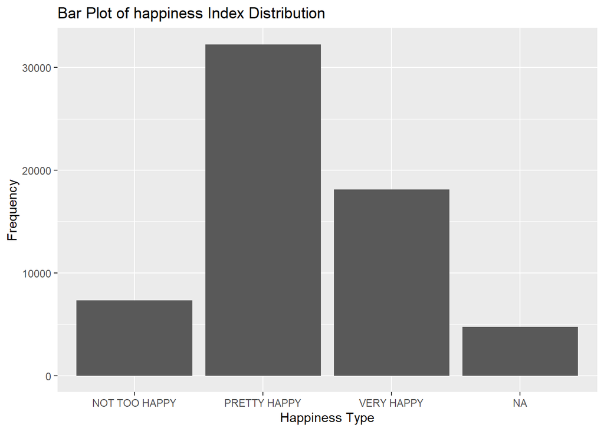

```r
ggplot(happy, aes(x=happy)) + geom_bar() + labs(title = "Bar Plot of happiness Index Distribution", x = "Happiness Type", y = "Frequency") #this barchart shows the distribution of the happiness index, as well as NA values in the happy column.
```

In total, there were 36,391 “missing” NA values through all 11 variables.

The variables were also cast into the correct type in order to ease data visualization. This was done by:

```r
str(happy) # Looked at the variables' data types to find that age should be converted to Integer
```

```
## 'data.frame':    62466 obs. of  11 variables:
##  $ happy   : chr  "NOT TOO HAPPY" "NOT TOO HAPPY" "PRETTY HAPPY" "NOT TOO HAPPY" ...
##  $ year    : int  1972 1972 1972 1972 1972 1972 1972 1972 1972 1972 ...
##  $ age     : chr  "23" "70" "48" "27" ...
##  $ sex     : chr  "FEMALE" "MALE" "FEMALE" "FEMALE" ...
##  $ marital : chr  "NEVER MARRIED" "MARRIED" "MARRIED" "MARRIED" ...
##  $ degree  : chr  "BACHELOR" "LT HIGH SCHOOL" "HIGH SCHOOL" "BACHELOR" ...
##  $ finrela : chr  "AVERAGE" "ABOVE AVERAGE" "AVERAGE" "AVERAGE" ...
##  $ health  : chr  "GOOD" "FAIR" "EXCELLENT" "GOOD" ...
##  $ wtssall : num  0.445 0.889 0.889 0.889 0.889 ...
##  $ partyid : chr  "IND,NEAR DEM" "NOT STR DEMOCRAT" "INDEPENDENT" "NOT STR DEMOCRAT" ...
##  $ polviews: chr  NA NA NA NA ...
```

```r
happy <- happy %>%
  mutate(age = replace(age, age == "89 OR OLDER", 89),age = as.numeric(age)) #used dplyr in order to mutate our happy dataframe, whilst using replace inside of the mutate argument in order to fulfill requirements, then used the final argument to change age's variable class from character to numeric.

str(happy) # displayed the structure of the new happy_clean to check if the variable age was successfully mutated
```

```
## 'data.frame':    62466 obs. of  11 variables:
##  $ happy   : chr  "NOT TOO HAPPY" "NOT TOO HAPPY" "PRETTY HAPPY" "NOT TOO HAPPY" ...
##  $ year    : int  1972 1972 1972 1972 1972 1972 1972 1972 1972 1972 ...
##  $ age     : num  23 70 48 27 61 26 28 27 21 30 ...
##  $ sex     : chr  "FEMALE" "MALE" "FEMALE" "FEMALE" ...
##  $ marital : chr  "NEVER MARRIED" "MARRIED" "MARRIED" "MARRIED" ...
##  $ degree  : chr  "BACHELOR" "LT HIGH SCHOOL" "HIGH SCHOOL" "BACHELOR" ...
##  $ finrela : chr  "AVERAGE" "ABOVE AVERAGE" "AVERAGE" "AVERAGE" ...
##  $ health  : chr  "GOOD" "FAIR" "EXCELLENT" "GOOD" ...
##  $ wtssall : num  0.445 0.889 0.889 0.889 0.889 ...
##  $ partyid : chr  "IND,NEAR DEM" "NOT STR DEMOCRAT" "INDEPENDENT" "NOT STR DEMOCRAT" ...
##  $ polviews: chr  NA NA NA NA ...
```

Factors were also organized into meaningful order as follows:

```r
library(dplyr)

happy_grouped = happy %>% group_by(marital) %>% mutate(avgAge = mean(age, na.rm= TRUE)) # Grouped the marital status in the dataset happy by the average age

happy_grouped$marital = reorder(happy_grouped$marital, happy_grouped$avgAge) # Based on the the code we pulled from eda; the order in which the dataframe is presented is originally grouped by marital status as well as average age, this is why we see people, for example, with the marital status of never married having a lower average as then say, someone who has been widowed will have a typically higher average age.

#happy_grouped #Called to check the grouping of our variables.
```

We decided to group by marital status, while creating a new column that computes the average age of any person that falls under that certain status, which we then used reorder to implement our changes.

## Data Exploration

Two variables of interest are `Age` and `Marital Status`. We also wanted to check how `Happiness` relates to `Age` as well, and both of those distributions are as follow:

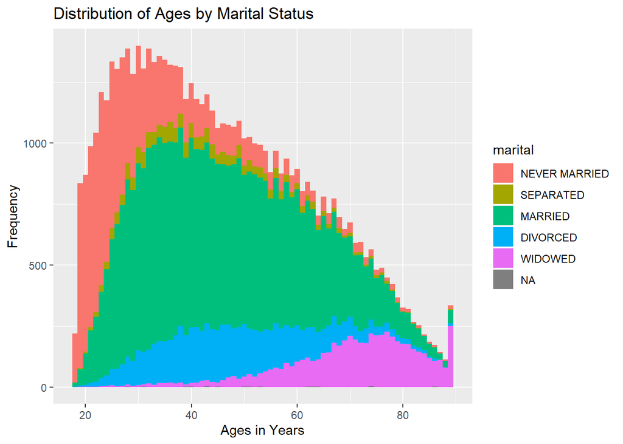

```r
library(ggplot2)

#Here is a Histogram showing the distribution of ages by different marital statuses.

ggplot(happy_grouped, aes(age, fill = marital)) + geom_histogram(binwidth = 1) + labs(title = "Distribution of Ages by Marital Status", x = "Ages in Years", y = "Frequency")
```

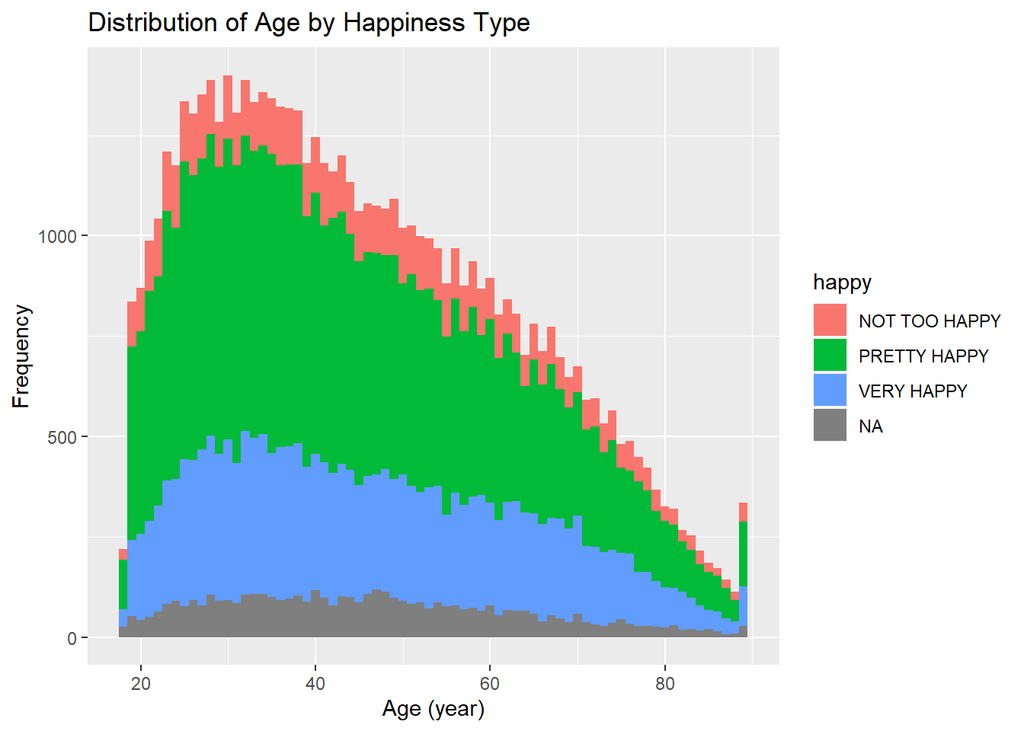

```r
#Here is a Histogram showing the distribution of ages by different happiness types.

ggplot(happy_grouped, aes(age, fill = happy)) + geom_histogram(binwidth = 1) + labs(title = "Distribution of Age by Happiness Type", x = "Age (year)", y = "Frequency")
```

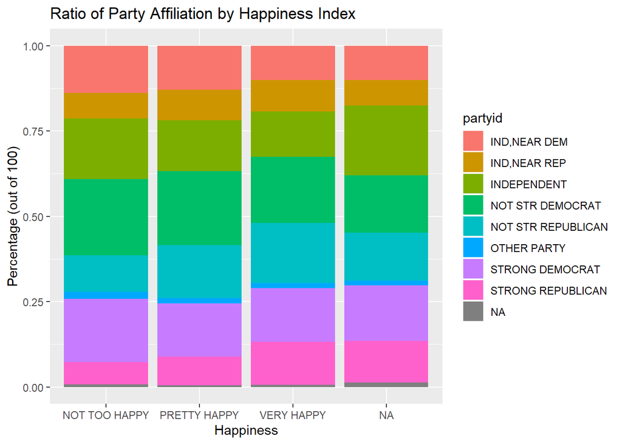

```r
#Here is a bar chart showing the ratios of each party type by the type of happiness.

ggplot(happy, aes(happy, fill = partyid)) + geom_bar(position = 'fill') + labs(title = "Ratio of Party Affiliation by Happiness Index", x = "Happiness", y = "Percentage (out of 100)")
```

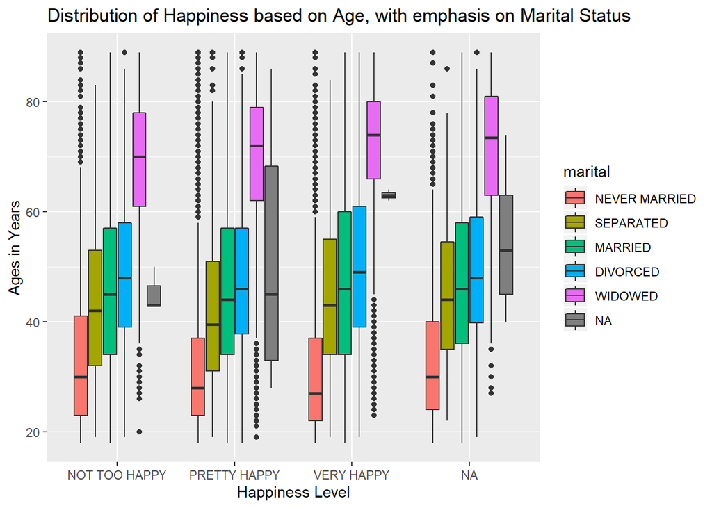

```r
#Boxplot of ages and happiness levels, with emphasis upon marital status.
ggplot(happy_grouped, aes(happy, age, fill = marital)) + geom_boxplot() + labs(title = "Distribution of Happiness based on Age, with emphasis on Marital Status", x = "Happiness Level", y = "Ages in Years")
```